# 3조 Team Project

김경일, 손상우, 주현우, 임낙현, 정지현

2022.02.13 일요일

#### **문제1. 약수와 소수 구하기**

1-1) n이 입력값으로 주어질 때 약수의 개수를 출력하는 함수를 완성하시오

```r
div_count <- function(n) sum(n%%(1:n)==0)
div_count(100)
```

```
## [1] 9
```

1-2) n이 입력값으로 주어질 때 소수의 개수를 출력하는 함수를 완성하시오

```r
prime_count <- function(n) sum(sapply(1:n,div_count)==2)
prime_count(100)
```

```
## [1] 25
```

#### **문제2. mtcars 데이터셋**

2-1) mtcars 데이터셋의 구조를 확인하시오.

```r
str(mtcars)
```

```
## 'data.frame':    32 obs. of  11 variables:
##  $ mpg : num  21 21 22.8 21.4 18.7 18.1 14.3 24.4 22.8 19.2 ...
##  $ cyl : num  6 6 4 6 8 6 8 4 4 6 ...
##  $ disp: num  160 160 108 258 360 ...
##  $ hp  : num  110 110 93 110 175 105 245 62 95 123 ...
##  $ drat: num  3.9 3.9 3.85 3.08 3.15 2.76 3.21 3.69 3.92 3.92 ...
##  $ wt  : num  2.62 2.88 2.32 3.21 3.44 ...
##  $ qsec: num  16.5 17 18.6 19.4 17 ...
##  $ vs  : num  0 0 1 1 0 1 0 1 1 1 ...
##  $ am  : num  1 1 1 0 0 0 0 0 0 0 ...
##  $ gear: num  4 4 4 3 3 3 3 4 4 4 ...
##  $ carb: num  4 4 1 1 2 1 4 2 2 4 ...
```

2-2) mtcars 데이터셋의 요약정보를 확인하시오.

```r
summary(mtcars)
```

```
##       mpg             cyl             disp             hp
##  Min.   :10.40   Min.   :4.000   Min.   : 71.1   Min.   : 52.0
##  1st Qu.:15.43   1st Qu.:4.000   1st Qu.:120.8   1st Qu.: 96.5
##  Median :19.20   Median :6.000   Median :196.3   Median :123.0
##  Mean   :20.09   Mean   :6.188   Mean   :230.7   Mean   :146.7
##  3rd Qu.:22.80   3rd Qu.:8.000   3rd Qu.:326.0   3rd Qu.:180.0
##  Max.   :33.90   Max.   :8.000   Max.   :472.0   Max.   :335.0
##       drat             wt             qsec             vs
##  Min.   :2.760   Min.   :1.513   Min.   :14.50   Min.   :0.0000
##  1st Qu.:3.080   1st Qu.:2.581   1st Qu.:16.89   1st Qu.:0.0000
##  Median :3.695   Median :3.325   Median :17.71   Median :0.0000
##  Mean   :3.597   Mean   :3.217   Mean   :17.85   Mean   :0.4375
##  3rd Qu.:3.920   3rd Qu.:3.610   3rd Qu.:18.90   3rd Qu.:1.0000
##  Max.   :4.930   Max.   :5.424   Max.   :22.90   Max.   :1.0000
##        am              gear            carb
##  Min.   :0.0000   Min.   :3.000   Min.   :1.000
##  1st Qu.:0.0000   1st Qu.:3.000   1st Qu.:2.000
##  Median :0.0000   Median :4.000   Median :2.000
##  Mean   :0.4062   Mean   :3.688   Mean   :2.812
##  3rd Qu.:1.0000   3rd Qu.:4.000   3rd Qu.:4.000
##  Max.   :1.0000   Max.   :5.000   Max.   :8.000
```

2-3) gear의 개수가 4인 자동차 모델의 모든 열 정보를 추출하시오.

```r
mtcars[mtcars$gear==4,]
```

```
##                 mpg cyl  disp  hp drat    wt  qsec vs am gear carb
## Mazda RX4      21.0   6 160.0 110 3.90 2.620 16.46  0  1    4    4
## Mazda RX4 Wag  21.0   6 160.0 110 3.90 2.875 17.02  0  1    4    4
## Datsun 710     22.8   4 108.0  93 3.85 2.320 18.61  1  1    4    1
## Merc 240D      24.4   4 146.7  62 3.69 3.190 20.00  1  0    4    2
## Merc 230       22.8   4 140.8  95 3.92 3.150 22.90  1  0    4    2
## Merc 280       19.2   6 167.6 123 3.92 3.440 18.30  1  0    4    4
## Merc 280C      17.8   6 167.6 123 3.92 3.440 18.90  1  0    4    4
## Fiat 128       32.4   4  78.7  66 4.08 2.200 19.47  1  1    4    1
## Honda Civic    30.4   4  75.7  52 4.93 1.615 18.52  1  1    4    2
## Toyota Corolla 33.9   4  71.1  65 4.22 1.835 19.90  1  1    4    1
## Fiat X1-9      27.3   4  79.0  66 4.08 1.935 18.90  1  1    4    1
## Volvo 142E     21.4   4 121.0 109 4.11 2.780 18.60  1  1    4    2
```

2-4) gear의 개수가 4인 자동차 모델의 mpg, cyl, hp, wt 열 정보만 추출하시오.

```r
mtcars[mtcars$gear==4,c('mpg','cyl','hp','wt')]
```

```
##                 mpg cyl  hp    wt
## Mazda RX4      21.0   6 110 2.620
## Mazda RX4 Wag  21.0   6 110 2.875
## Datsun 710     22.8   4  93 2.320
## Merc 240D      24.4   4  62 3.190
## Merc 230       22.8   4  95 3.150
## Merc 280       19.2   6 123 3.440
## Merc 280C      17.8   6 123 3.440
## Fiat 128       32.4   4  66 2.200
## Honda Civic    30.4   4  52 1.615
## Toyota Corolla 33.9   4  65 1.835
## Fiat X1-9      27.3   4  66 1.935
## Volvo 142E     21.4   4 109 2.780
```

2-5) mpg가 가장 낮은 자동차 모델의 모든 열 정보를 추출하시오.

```r
mtcars[mtcars$mpg==min(mtcars$mpg),]
```

```
##                      mpg cyl disp  hp drat    wt  qsec vs am gear carb
## Cadillac Fleetwood  10.4   8  472 205 2.93 5.250 17.98  0  0    3    4
## Lincoln Continental 10.4   8  460 215 3.00 5.424 17.82  0  0    3    4
```

2-6) mpg가 가장 낮은 자동차 모델의 mpg, cyl, hp, wt 열 정보만 추출하시오.

```r
mtcars[mtcars$mpg==min(mtcars$mpg),c('mpg','cyl','hp','wt')]
```

```
##                      mpg cyl  hp    wt
## Cadillac Fleetwood  10.4   8 205 5.250
## Lincoln Continental 10.4   8 215 5.424
```

2-7) 연비(mpg)의 평균, 분산, 표준편차를 구하시오.

```r
mean(mtcars$mpg) # mpg의 평균
```

```
## [1] 20.09062
```

```r
var(mtcars$mpg) # mpg의 분산
```

```
## [1] 36.3241
```

```r
sd(mtcars$mpg) # mpg의 표준편차
```

```
## [1] 6.026948
```

2-8) 연비(mpg)가 중앙값(median)보다 큰 모델들의 평균, 표준편차를 구하시오.

```r
mean(subset(mtcars,mtcars$mpg>median(mtcars$mpg))$mpg) # 연비가 중앙값 보다 큰 모델들의 평균
```

```
## [1] 25.09333
```

```r
sd(subset(mtcars,mtcars$mpg>median(mtcars$mpg))$mpg) # 연비가 중앙값 보다 큰 모델들의 표준편차
```

```
## [1] 4.680883
```

2-9) 연비(mpg)의 히스토그램을 그리시오.

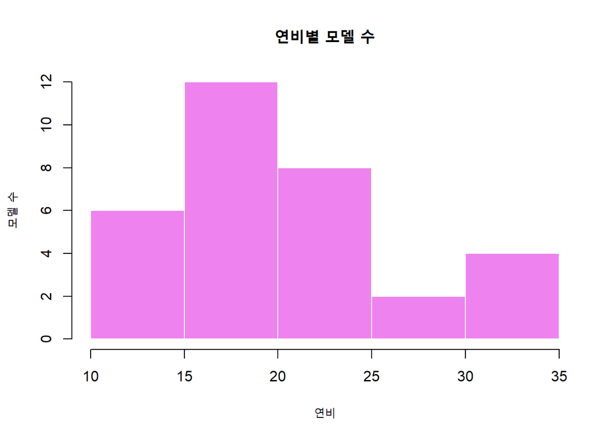

```r
hist(mtcars$mpg,main='연비별 모델 수',col="violet",border="white",xlab="연비",ylab='모델 수')
```

2-10) 기어(gear)의 개수에 따른 빈도수를 나타내는 barplot을 그리시오.

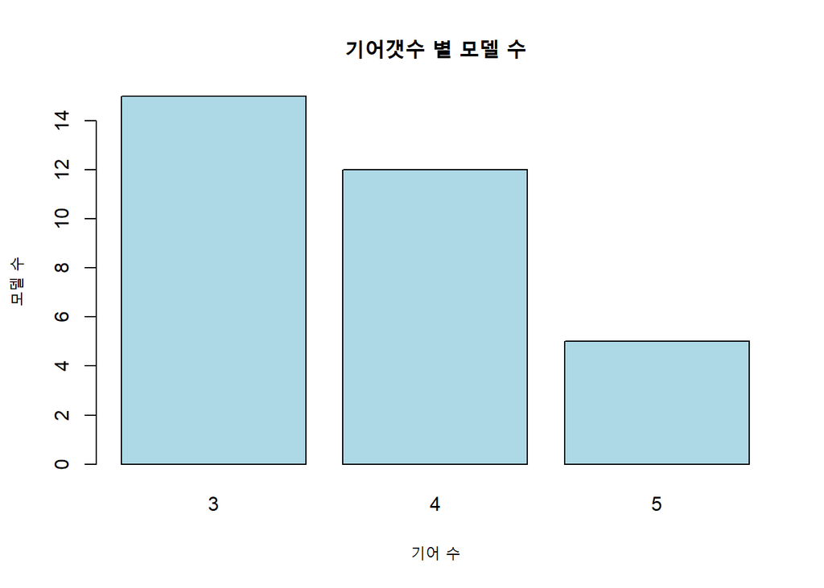

```r
barplot(table(mtcars$gear),main='기어갯수 별 모델 수',col="lightblue",xlab="기어 수",ylab="모델 수")
```

2-11) mpg와 wt와의 관계를 나타내는 산점도(scatter plot)를 그리시오.

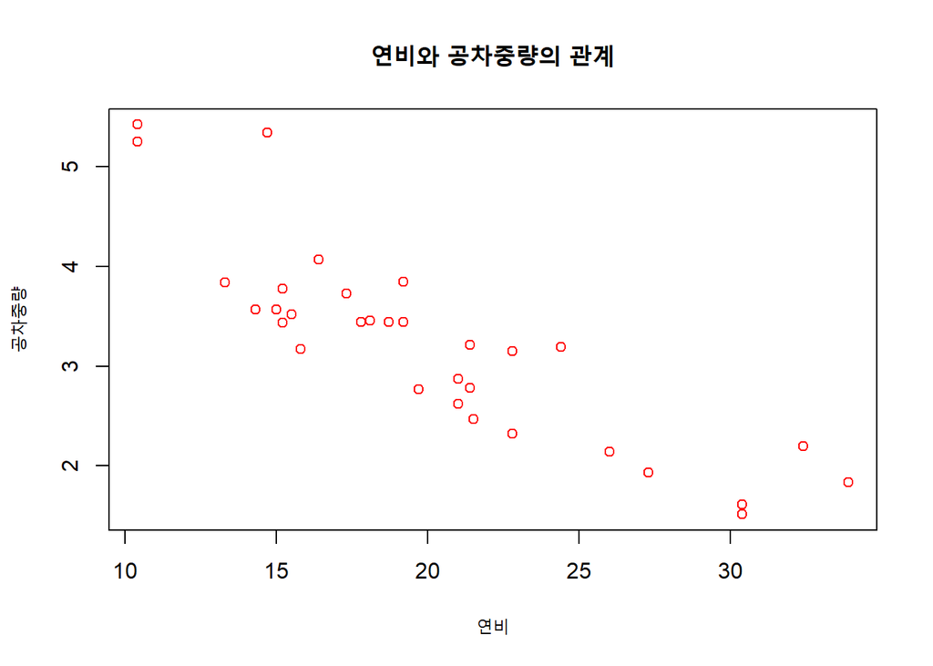

```r
plot(x=mtcars$mpg,y=mtcars$wt,main='연비와 공차중량의 관계',col='red',xlab='연비',ylab='공차중량')
```

#### **문제3. state.x77 데이터셋**

3-1) state.x77 데이터셋의 각 변수값에 대해 조사하시오.

```r
?state.x77
```

```
## starting httpd help server ... done
```

3-2) state.x77 데이터셋의 데이터 프레임을 분석하시오.

```r
st <- as.data.frame(state.x77)
str(st)
```

```
## 'data.frame':    50 obs. of  8 variables:
##  $ Population: num  3615 365 2212 2110 21198 ...
##  $ Income    : num  3624 6315 4530 3378 5114 ...
##  $ Illiteracy: num  2.1 1.5 1.8 1.9 1.1 0.7 1.1 0.9 1.3 2 ...
##  $ Life Exp  : num  69 69.3 70.5 70.7 71.7 ...
##  $ Murder    : num  15.1 11.3 7.8 10.1 10.3 6.8 3.1 6.2 10.7 13.9 ...
##  $ HS Grad   : num  41.3 66.7 58.1 39.9 62.6 63.9 56 54.6 52.6 40.6 ...
##  $ Frost     : num  20 152 15 65 20 166 139 103 11 60 ...
##  $ Area      : num  50708 566432 113417 51945 156361 ...
```

```r
summary(st)
```

```
##    Population        Income       Illiteracy       Life Exp
##  Min.   :  365   Min.   :3098   Min.   :0.500   Min.   :67.96
##  1st Qu.: 1080   1st Qu.:3993   1st Qu.:0.625   1st Qu.:70.12
##  Median : 2838   Median :4519   Median :0.950   Median :70.67
##  Mean   : 4246   Mean   :4436   Mean   :1.170   Mean   :70.88
##  3rd Qu.: 4968   3rd Qu.:4814   3rd Qu.:1.575   3rd Qu.:71.89
##  Max.   :21198   Max.   :6315   Max.   :2.800   Max.   :73.60
##      Murder          HS Grad          Frost             Area
##  Min.   : 1.400   Min.   :37.80   Min.   :  0.00   Min.   :  1049
##  1st Qu.: 4.350   1st Qu.:48.05   1st Qu.: 66.25   1st Qu.: 36985
##  Median : 6.850   Median :53.25   Median :114.50   Median : 54277
##  Mean   : 7.378   Mean   :53.11   Mean   :104.46   Mean   : 70736
##  3rd Qu.:10.675   3rd Qu.:59.15   3rd Qu.:139.75   3rd Qu.: 81163
##  Max.   :15.100   Max.   :67.30   Max.   :188.00   Max.   :566432
```

3-3) state.x77 데이터셋의 각 변수별 기술적 통계량을 분석하시오.

```r
summary(st$Population)
```

```
##    Min. 1st Qu.  Median    Mean 3rd Qu.    Max.
##     365    1080    2838    4246    4968   21198
```

```r
summary(st$Income)
```

```
##    Min. 1st Qu.  Median    Mean 3rd Qu.    Max.
##    3098    3993    4519    4436    4814    6315
```

```r
summary(st$Illiteracy)
```

```
##    Min. 1st Qu.  Median    Mean 3rd Qu.    Max.
##   0.500   0.625   0.950   1.170   1.575   2.800
```

```r
summary(st$`Life Exp`)
```

```
##    Min. 1st Qu.  Median    Mean 3rd Qu.    Max.
##   67.96   70.12   70.67   70.88   71.89   73.60
```

```r
summary(st$Murder)
```

```
##    Min. 1st Qu.  Median    Mean 3rd Qu.    Max.
##   1.400   4.350   6.850   7.378  10.675  15.100
```

```r
summary(st$`HS Grad`)
```

```
##    Min. 1st Qu.  Median    Mean 3rd Qu.    Max.
##   37.80   48.05   53.25   53.11   59.15   67.30
```

```r
summary(st$Area)
```

```
##    Min. 1st Qu.  Median    Mean 3rd Qu.    Max.
##    1049   36985   54277   70736   81163  566432
```

3-4) state.x77 데이터셋의 각 변수별 확률분포를 시각화하시오.

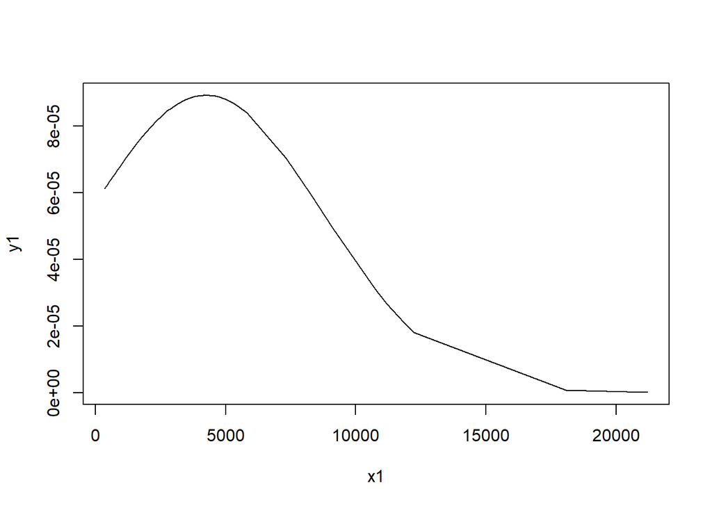

```r
# Population 확률분포 시각화
x1 <- sort(st$Population)
y1 <- dnorm(x1,mean(x1),sd(x1))
plot(x1,y1,type='l')
```

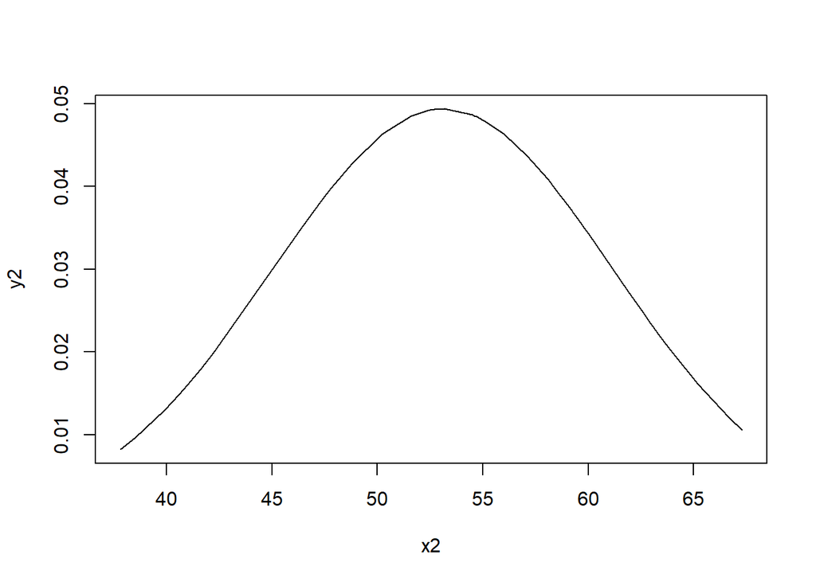

```r
# HS Grad 확률분포 시각화
x2 <- sort(st$`HS Grad`)
y2 <- dnorm(x2, mean(x2), sd(x2))
plot(x2, y2, type='l')
```

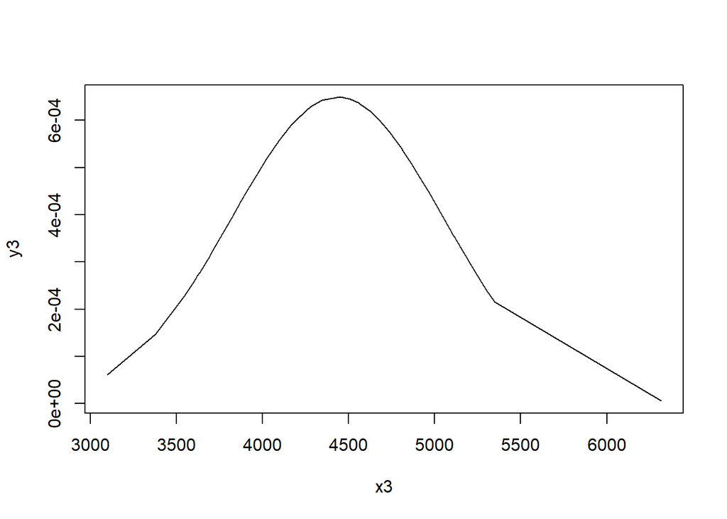

```r
# Income 확률분포 시각화
x3 <- sort(st$Income)
y3 <- dnorm(x3, mean(x3), sd(x3))
plot(x3, y3, type='l')
```

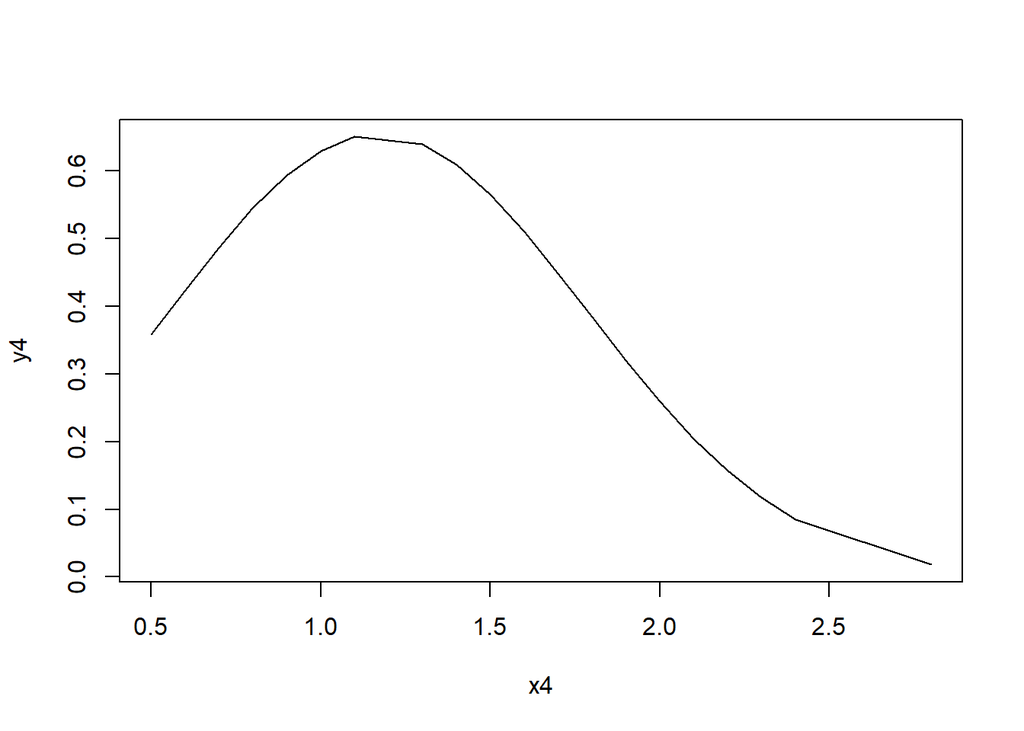

```r
# Illiteracy 확률분포 시각화
x4 <- sort(st$Illiteracy)
y4 <- dnorm(x4, mean(x4), sd(x4))
plot(x4, y4, type='l')
```

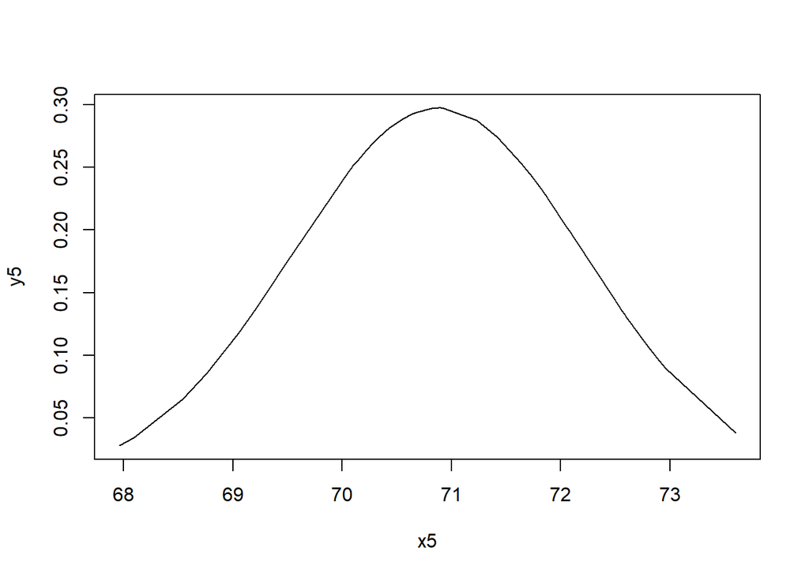

```r
# Life Exp 확률분포 시각화
x5 <- sort(st$`Life Exp`)
y5 <- dnorm(x5, mean(x5), sd(x5))
plot(x5, y5, type='l')
```

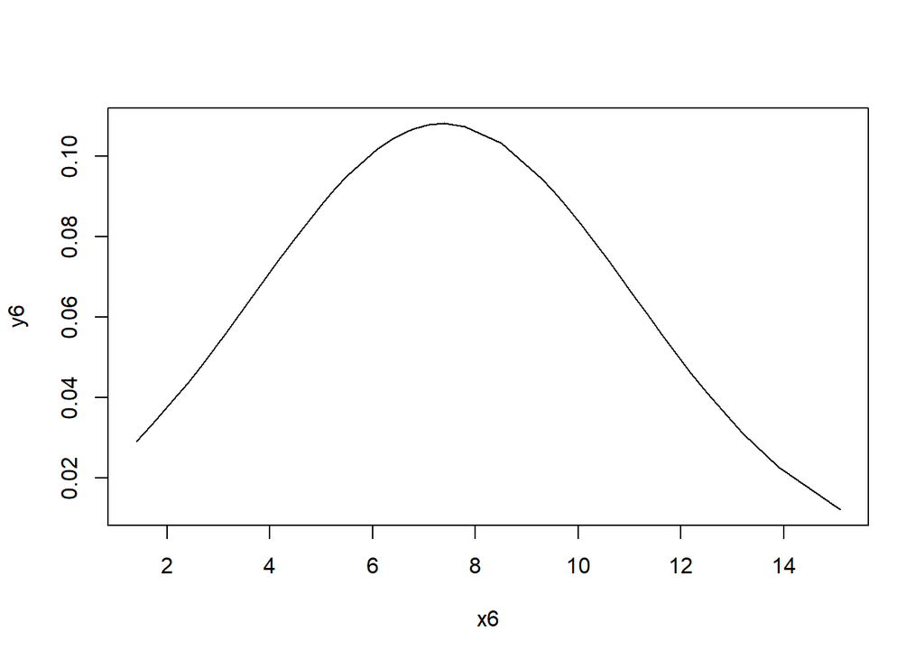

```r
# Murder 확률분포 시각화
x6 <- sort(st$Murder)
y6 <- dnorm(x6, mean(x6), sd(x6))
plot(x6, y6, type='l')
```

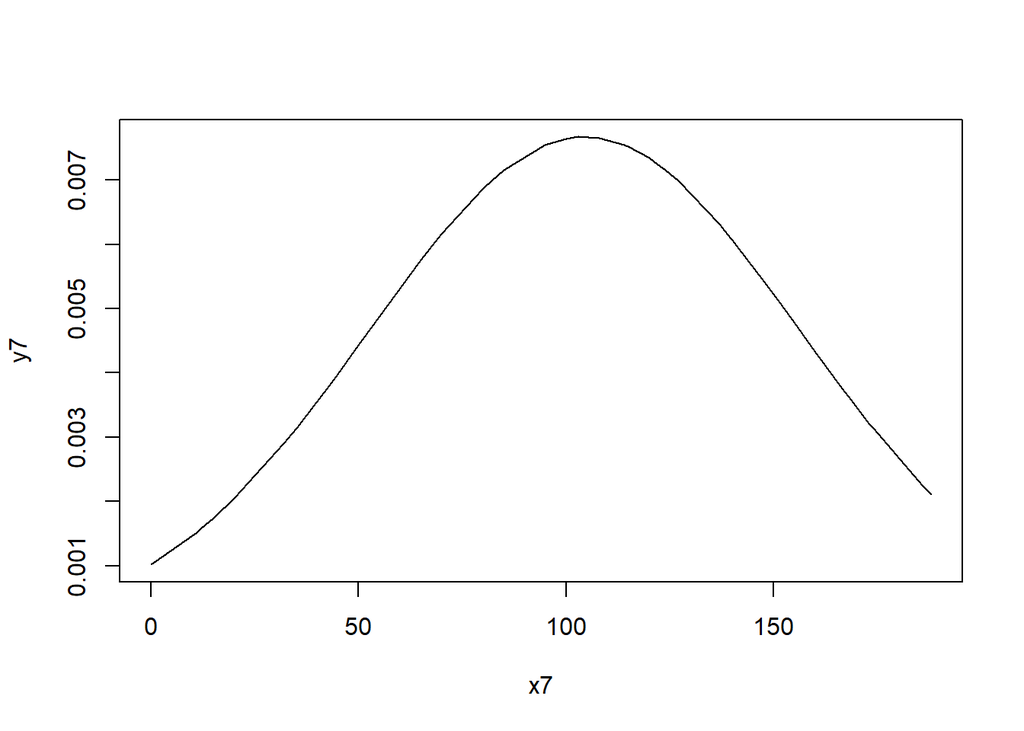

```r
# Frost 확률분포 시각화
x7 <- sort(st$Frost)
y7 <- dnorm(x7, mean(x7), sd(x7))
plot(x7, y7, type='l')
```

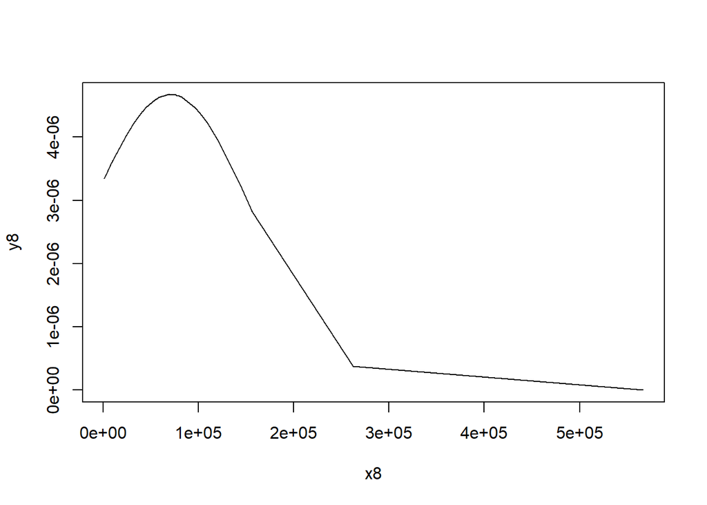

```r
# Area 확률분포 시각화
x8 <- sort(st$Area)
y8 <- dnorm(x8, mean(x8), sd(x8))
plot(x8, y8, type='l')
```

3-5) state.x77 데이터셋의 각 변수간의 관계에 대해 분석하고 시각화하시오.

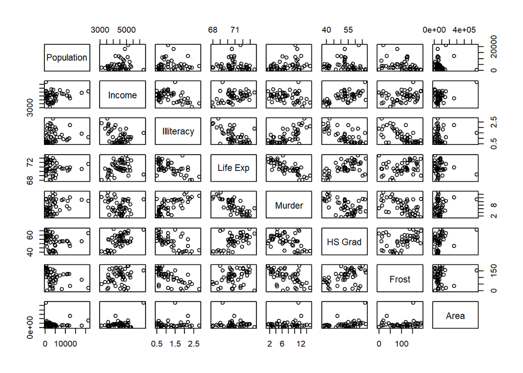

```r
plot(st)
```

3-6) state.x77 데이터셋을 대상으로 통계적 분석을 실행하고 통계적 분석을 통해 얻은 분석 결과를 기술하시오 예)변수간 상관관계가 가장 높은 두 변수는 Murder 와 Illiteracy 이다

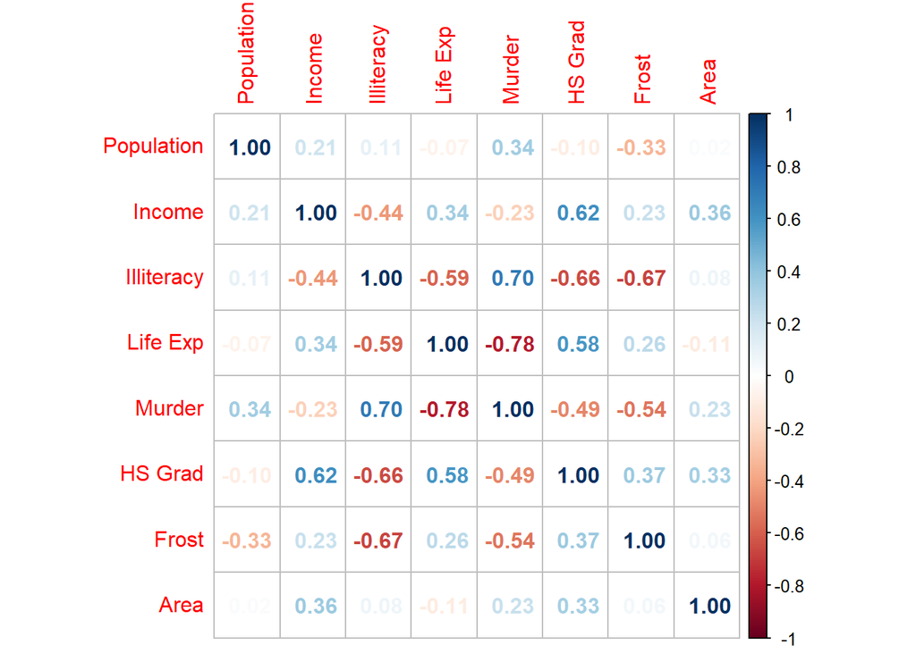

```r
#install.packages("corrplot")
library(corrplot)
corrplot(cor(st), method="number")
```

#### **문제4. 생활속에 통계학 확률분포 문제 풀이**

5단원.

13. 어떤 자동차 보험회사가 자사 보험 가입 운전자의 성향이 연간 0.6의 확률을 가지고 추돌사고를 일으킨다는 정보를 가지고 있다. 이 보험회사의 자동차보험에 가입한 10명의 피보험자를 무작위로 선정할 경우, 다음을 구하라.

13-1) 추돌사고를 일으킨 피보험자 수에 대한 확률함수.

```r
aig <- function(n) dbinom(n,10,0.6)
```

13-2) 추돌사고를 일으킨 피보험자 수의 평균과 분산.

```r
mean13 <- 10*0.6
mean13 # 평균
```

```
## [1] 6
```

```r
sd13 <- 10*0.6*0.4
sd13 # 분산
```

```
## [1] 2.4
```

13-3) 꼭 두 명의 피보험자가 사고를 낼 확률.

```r
aig(2)
```

```
## [1] 0.01061683
```

13-4) 적어도 4명 이상의 피보험자가 사고를 낼 확률.

```r
1-pbinom(3,10,0.6) # 1에서 3명까지의 피보험자가 사고를 낼 확률을 빼서 구했습니다.
```

```
## [1] 0.9452381
```

16. 치명적인 자동차 사고의 55%가 음주운전에 의한 것이라는 보고가 있다. 앞으로 5건의 치명적인 자동차 사고가 날 때, 음주운전에 의하여 사고가 발생한 횟수 X에 대하여 다음 확률을 구하라.

16-1) 다섯 번 모두 사고가 날 확률.

```r
car_crash <- function(n) dbinom(n,5,0.55) #16번 문제의 확률함수입니다.
car_crash(5)
```

```
## [1] 0.05032844
```

16-2) 꼭 3번 사고가 날 확률.

```r
car_crash(3)
```

```
## [1] 0.3369094
```

16-3) 적어도 1번 이상 사고가 날 확률.

```r
1-car_crash(0)
```

```
## [1] 0.9815472
```

6단원.

2. X~N(5,4)일 때, 다음을 구하라.

2-1) P(X>=4.5)

```r
pnorm(4.5,5,2,F)
```

```
## [1] 0.5987063
```

2-2) P(X<6.5)

```r
pnorm(6.5,5,2)
```

```
## [1] 0.7733726
```

2-3) P(X<=2.5)

```r
pnorm(2.5,5,2)
```

```
## [1] 0.1056498
```

2-4) P(3<=X<=7)

```r
pnorm(7,5,2)-pnorm(3,5,2)
```

```
## [1] 0.6826895
```

19. 집에서 학교까지 걸어서 가는 시간이 평균 10분이고 표준편차는 1.5분인 정규분포를 따른다고 하자. 이때 집에서 학교까지 걸어서 가는 데 걸리는 시간에 대하여 다음을 구하라.

19-1) 집에서 출발하여 걸어서 학교까지 가는 데 12분 이상 걸릴 확률.

```r
pnorm(12,10,1.5,F)
```

```
## [1] 0.09121122
```

19-2) 집에서 출발하여 걸어서 9분 안에 학교에 도착할 확률.

```r
pnorm(9,10,1.5)
```

```
## [1] 0.2524925
```

19-3) 집에서 학교까지 걸어서 7분 이상 걸리지만 11분 안에 도착할 확률.

```r
pnorm(11,10,1.5)-pnorm(7,10,1.5)
```

```
## [1] 0.7247573
```

7단원.

3. M=50 이고 모표준편차가 다음과 같은 모집단으로부터 크기 25인 확률표본을 선정할 때, 표본 평균이 49와 52 사이일 확률을 구하라.

3-1) 모표준편차=4

```r
#모표준편차가 주어졌을 때 표본 평균이 49와 52 사이일 확률을 구해주는 함수입니다.
mean_guess <- function(x) pnorm(2/(x/5),0,1)-pnorm(-1/(x/5),0,1)

mean_guess(4)
```

```
## [1] 0.8881406
```

3-2) 모표준편차=9

```r
mean_guess(9)
```

```
## [1] 0.5774824
```

3-3) 모표준편차=12

```r
mean_guess(12)
```

```
## [1] 0.4592105
```

21. 2014년 7월 26일자 동아일보에 ’전년도 해외여행자 수가 1484만 6천 명으로 역대 최고를 기록했다.’라는 기사가 실렸다. 이는 전 국민의 약 30%에 해당하는 비율이다. 2015년도에 해외여행을 계획하는 사람의 비율을 조사하기 위하여, 500명을 임의로 선정하여 조사하였다. 물음에 답하라.

21-1) 표본비율의 근사 확률분포를 구하라.

```r
phat21 <- 0.3 # 모비율입니다.
p_sd21 <- sqrt(0.3*(1-0.3)/500) # 모비율로 구한 표p본비율이 따르는 확률분포의 표준편차 입니다.
#표본비율의 근사 확률분포 : N(phat21,p_sd21)
```

21-2) 표본비율과 모비율의 차가 0.05보다 작을 확률을 구하라.

```r
pnorm((0.35-phat21)/p_sd21,0,1)-pnorm((0.25-phat21)/p_sd21,0,1)
```

```
## [1] 0.9853026
```

21-3) 표본비율이 p0보다 클 확률이 0.025인 p0을 구하라.

```r
p0 <- 1.96*p_sd21+phat21
p0
```

```
## [1] 0.340168
```

8단원.

15. 2014년에 한국소비자보호원은 서울 지역 자가 운전자 1000명을 대상으로 설문 조사를 실시한 결과, 가짜 석유 또는 정량 미달 주유를 의심한 경험이 있는 소비자가 79.3%에 이르는 것으로 나타났다고 밝혔다. 이와 같은 경험을 가진 서울 지역 자가 운전자의 비율에 대한 90% 신뢰구간을 구하라.

```r
merror21 <- 1.645*sqrt(0.793*(1-0.793)/1000) # 오차한계
0.793-merror21 #신뢰구간의 하한
```

```
## [1] 0.771924
```

```r
0.793+merror21 #신뢰구간의 상한
```

```
## [1] 0.814076
```

```r
#서울 지역 자가 운전자의 비율에 대한 90% 신뢰구간 : (0.793-merror21, 0.793+merror21)
```

20. 한강의 물속에 포함된 염분의 평균 농도를 구하고자 한다. 95% 신뢰구간의 길이가 0.4를 넘지 않도록 하기 위한 최소한의 표본의 크기를 구하라(단, 염분의 농도에 대한 표준편차는 3인 것으로 알려져 있다고 한다).

```r
((2*1.96*3)/0.4)^2 #신뢰구간의 길이가 0.4를 넘지 않게하는 최소한의 표본의 크기
```

```
## [1] 864.36
```